# PCFL: Week 7 wrap-up

### Last week’s games

| Away | Away points | Home | Home points |
| --- | --- | --- | --- |
| Georgia Peanuts | 163.68 | The G.O.A.T. | 105.30 |
| Jumpin’ Jaheims | 111.03 | First Timers The FTs | 60.10 |
| Southern Sharks | 125.26 | KC Gophers | 89.42 |
| Captain Clairvoyant | 98.12 | Athens Team Sasquatch | 115.52 |
| Pigskin on the Gridiron | 131.56 | Middle Earth Hangry Hobbits | 124.36 |

Unlike last week, most games this week weren’t particularly close, with an average margin of victory around 35 points. Richard’s narrow win over Scott was the one exception. Bye weeks and injuries also definitely sapped some teams. The most notable matchup was Robbie’s Sasquatch stomping Brian’s Captain Clairvoyant squad in a battle for the league’s best record. My Peanuts also had a record week–more on that later on.

Overall, a reminder that as we reach midseason, you should make sure to check your bye weeks and also whether your stars are active at gametime.

#### Best performing players

Here’s last week’s **10 best performing players.** The bench variable shows whether they got left on the bench or not.

| Player | Points | Team | Benched |
| --- | --- | --- | --- |
| Tyler Lockett | 46.95 | Jumpin’ Jaheims | 0 |
| Davante Adams | 39.10 | Georgia Peanuts | 0 |
| Justin Herbert | 38.48 | Georgia Peanuts | 0 |
| Kyler Murray | 37.10 | The G.O.A.T. | 0 |
| Tom Brady | 36.86 | Pigskin on the Gridiron | 0 |
| Joe Burrow | 33.64 | KC Gophers | 1 |
| Russell Wilson | 29.92 | Southern Sharks | 0 |
| James Robinson | 29.70 | Georgia Peanuts | 0 |
| Carson Wentz | 27.76 | First Timers The FTs | 1 |
| Aaron Rodgers | 27.32 | Captain Clairvoyant | 0 |

Tyler Lockett had a great week for Evan’s team, tallying nearly 50 points. I was also grateful to Evan for giving me Justin Herbert, the league’s top scording QB last week. Tom Brady and Joe Burrow–the old and new guard–also did quite well, though Burrow apparently did so on the bench.

#### Best addition and worst starters

There were 25 players added last week. Which was the **best new addition**?

| Date added | Name | Points | Team |
| --- | --- | --- | --- |
| 2020-10-22 | Justin Herbert | 38.48 | Georgia Peanuts |
| 2020-10-23 | Chiefs D/ST | 21.00 | Athens Team Sasquatch |
| 2020-10-25 | Jamaal Williams | 19.40 | Athens Team Sasquatch |
| 2020-10-23 | Giovani Bernard | 19.30 | Athens Team Sasquatch |
| 2020-10-21 | Teddy Bridgewater | 19.16 | Athens Team Sasquatch |
| 2020-10-22 | Chase Edmonds | 19.05 | Jumpin’ Jaheims |
| 2020-10-22 | Gardner Minshew II | 19.02 | Jumpin’ Jaheims |
| 2020-10-25 | Cole Beasley | 16.70 | Jumpin’ Jaheims |
| 2020-10-21 | Bills D/ST | 16.00 | Pigskin on the Gridiron |
| 2020-10-21 | D’Andre Swift | 12.80 | Captain Clairvoyant |
| 2020-10-22 | Leonard Fournette | 12.70 | Captain Clairvoyant |
| 2020-10-22 | Wil Lutz | 11.00 | Middle Earth Hangry Hobbits |
| 2020-10-22 | Randy Bullock | 10.00 | Southern Sharks |
| 2020-10-21 | Bears D/ST | 10.00 | Captain Clairvoyant |
| 2020-10-21 | Eagles D/ST | 9.00 | Georgia Peanuts |
| 2020-10-25 | Daniel Carlson | 9.00 | First Timers The FTs |
| 2020-10-23 | Zack Moss | 8.70 | Georgia Peanuts |
| 2020-10-21 | Justin Jackson | 8.00 | Georgia Peanuts |
| 2020-10-22 | Mike Davis | 6.10 | Jumpin’ Jaheims |
| 2020-10-21 | DJ Chark Jr. | 3.10 | Jumpin’ Jaheims |
| 2020-10-21 | Giants D/ST | 2.00 | Southern Sharks |
| 2020-10-23 | Keelan Cole Sr. | 1.70 | Pigskin on the Gridiron |
| 2020-10-25 | Mike Williams | 0.90 | First Timers The FTs |
| 2020-10-21 | Jerick McKinnon | -0.10 | Jumpin’ Jaheims |
| 2020-10-22 | Seahawks D/ST | -5.00 | Middle Earth Hangry Hobbits |

A whole lot of new additions last week! Robbie and Evan were both victorious last week, and that was clearly partially due to their new additions. The normally reliable Seahawks defense did not serve Scott well, continuing a trend of defenses with negative points.

Who should have been **left on the bench** this week–the lowest points scored by starters?

| Name | Points | Team |
| --- | --- | --- |
| Seahawks D/ST | -5.0 | Middle Earth Hangry Hobbits |
| Jerick McKinnon | -0.1 | Jumpin’ Jaheims |
| Aaron Jones | 0.0 | First Timers The FTs |
| Odell Beckham Jr. | 0.0 | First Timers The FTs |
| Tyler Higbee | 0.0 | First Timers The FTs |
| Joe Mixon | 0.0 | KC Gophers |
| Lamar Jackson | 0.0 | Athens Team Sasquatch |
| Mark Andrews | 0.0 | Athens Team Sasquatch |

Uff-da, Jerick McKinnon. The First Timers also had some exceptionally bad luck: Aaron Jones not being active and now Odell out for the season with an ACL. (Note–this table still needs work, as both Jackson and Andrews were on Robbie’s bench. More work needed in the software development office.)

Who won the **best scoring bench** award last week?

| Team | Points |
| --- | --- |
| KC Gophers | 95.24 |
| Captain Clairvoyant | 91.03 |
| Jumpin’ Jaheims | 84.77 |
| Pigskin on the Gridiron | 71.40 |
| Athens Team Sasquatch | 67.28 |
| First Timers The FTs | 65.11 |
| Georgia Peanuts | 63.22 |
| The G.O.A.T. | 59.57 |
| Middle Earth Hangry Hobbits | 32.10 |
| Southern Sharks | 23.14 |

I joked with Sarah that halfway through the games her bench hadn’t yet broken a single point. They ended up with 23, but that’s still quite low. Christine and Brian were at the top of the list last week (and perhaps unsurprisingly both ended up in the L column).

### League standings and season stats

Here’s a look at our current standings

| Team | Division | W | L | Points scored | Points allowed | Points rank | Playoff rank |
| --- | --- | --- | --- | --- | --- | --- | --- |
| Athens Team Sasquatch | Grits | 6 | 1 | 817.37 | 786.70 | 5 | 1 |
| Captain Clairvoyant | Grits | 5 | 2 | 844.99 | 771.34 | 2 | 2 |
| Georgia Peanuts | Hot Dish | 4 | 3 | 851.06 | 800.57 | 1 | 3 |
| The G.O.A.T. | Grits | 4 | 3 | 824.61 | 847.72 | 4 | 4 |
| Southern Sharks | Hot Dish | 4 | 3 | 802.92 | 760.11 | 7 | 5 |
| First Timers The FTs | Hot Dish | 3 | 4 | 835.78 | 800.19 | 3 | 6 |
| KC Gophers | Hot Dish | 3 | 4 | 719.99 | 768.61 | 10 | 7 |
| Middle Earth Hangry Hobbits | Hot Dish | 2 | 5 | 804.88 | 818.61 | 6 | 8 |
| Pigskin on the Gridiron | Grits | 2 | 5 | 746.90 | 836.84 | 8 | 9 |
| Jumpin’ Jaheims | Grits | 2 | 5 | 738.92 | 796.73 | 9 | 10 |

Here’s our current awards leaders from these standings:

- Yellow shirt (most points): Georgia Peanuts
- D-FENCE (least points allowed): Southern Sharks
- Tough luck (points rank - playoff rank): First Timers
- Lucky ducks (playoff rank - points rank): Team Sasquatch

Here’s a list of the **top five scoring performances** so far this season.

| Team | Week | Points scored | Result |
| --- | --- | --- | --- |
| First Timers The FTs | 2 | 171.28 | W |
| Georgia Peanuts | 7 | 163.68 | W |
| Captain Clairvoyant | 3 | 150.32 | W |
| Middle Earth Hangry Hobbits | 5 | 142.36 | W |
| First Timers The FTs | 4 | 141.14 | W |

My Peanuts cracked onto the list at #2 after last week’s performance.

Lastly, here’s a look at the **points trendline** for each team.

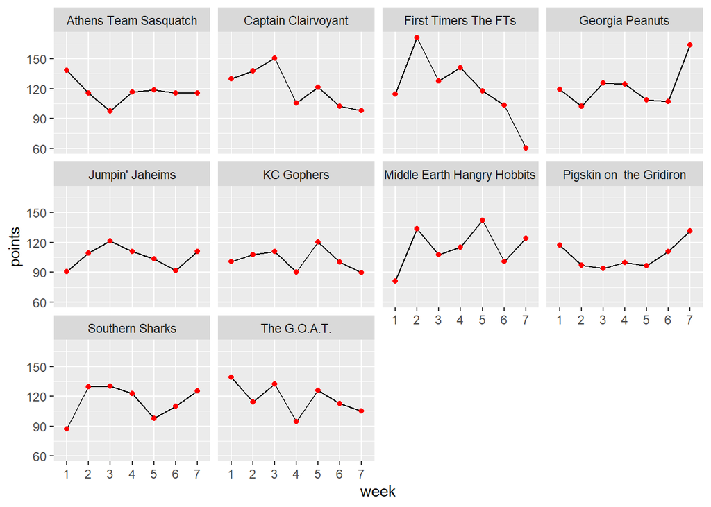

## Next week’s games

Here’s a quick summary of next week’s matchups:

| week | away_team | away_points | home_team | home_points | range |
| --- | --- | --- | --- | --- | --- |
| 8 | First Timers The FTs | 835.78 | Georgia Peanuts | 851.06 | 15.28 |
| 8 | KC Gophers | 719.99 | Jumpin’ Jaheims | 738.92 | 18.93 |
| 8 | Athens Team Sasquatch | 817.37 | Southern Sharks | 802.92 | 14.45 |
| 8 | Middle Earth Hangry Hobbits | 804.88 | Captain Clairvoyant | 844.99 | 40.11 |
| 8 | The G.O.A.T. | 824.61 | Pigskin on the Gridiron | 746.90 | 77.71 |

Family match up week: Richard and Jacob go head to head, while I face off against Erin/Trav in an in-law battle. Sarah takes her shot against the league leader, Robbie, while Scott tries to stay playoff relevant against Brian. Lastly, both Christine and Evan could use a win to stay in the playoff hunt. Good luck all!